# Prosper Loan Data Exploration

## Introduction

Prosper is a P2P lending platform that allows investors to choose among personal loans to invest in. They do that by considering a number of factors, which include a custom calculated Prosper Score that represents the risk for each loan. The higher the score, the lower the risk, and the lower the interest rates paid by the borrower to the investors.

## Preliminary Wrangling

```python
# import all packages and set plots to be embedded inline
import numpy as np
import pandas as pd
import matplotlib.pyplot as plt
import seaborn as sb

%matplotlib inline
```

```python
# Loading in the csv file to a dataframe and geting an overview with the head() function
df = pd.read_csv("prosperLoanData.csv")
df.head(5)
```

|  | ListingKey | ListingNumber | ListingCreationDate | CreditGrade | Term | LoanStatus | ClosedDate | BorrowerAPR | BorrowerRate | LenderYield | ... | LP_ServiceFees | LP_CollectionFees | LP_GrossPrincipalLoss | LP_NetPrincipalLoss | LP_NonPrincipalRecoverypayments | PercentFunded | Recommendations | InvestmentFromFriendsCount | InvestmentFromFriendsAmount | Investors |
| --- | --- | --- | --- | --- | --- | --- | --- | --- | --- | --- | --- | --- | --- | --- | --- | --- | --- | --- | --- | --- | --- |
| 0 | 1021339766868145413AB3B | 193129 | 2007-08-26 19:09:29.263000000 | C | 36 | Completed | 2009-08-14 00:00:00 | 0.16516 | 0.1580 | 0.1380 | ... | -133.18 | 0.0 | 0.0 | 0.0 | 0.0 | 1.0 | 0 | 0 | 0.0 | 258 |
| 1 | 10273602499503308B223C1 | 1209647 | 2014-02-27 08:28:07.900000000 | NaN | 36 | Current | NaN | 0.12016 | 0.0920 | 0.0820 | ... | 0.00 | 0.0 | 0.0 | 0.0 | 0.0 | 1.0 | 0 | 0 | 0.0 | 1 |
| 2 | 0EE9337825851032864889A | 81716 | 2007-01-05 15:00:47.090000000 | HR | 36 | Completed | 2009-12-17 00:00:00 | 0.28269 | 0.2750 | 0.2400 | ... | -24.20 | 0.0 | 0.0 | 0.0 | 0.0 | 1.0 | 0 | 0 | 0.0 | 41 |
| 3 | 0EF5356002482715299901A | 658116 | 2012-10-22 11:02:35.010000000 | NaN | 36 | Current | NaN | 0.12528 | 0.0974 | 0.0874 | ... | -108.01 | 0.0 | 0.0 | 0.0 | 0.0 | 1.0 | 0 | 0 | 0.0 | 158 |
| 4 | 0F023589499656230C5E3E2 | 909464 | 2013-09-14 18:38:39.097000000 | NaN | 36 | Current | NaN | 0.24614 | 0.2085 | 0.1985 | ... | -60.27 | 0.0 | 0.0 | 0.0 | 0.0 | 1.0 | 0 | 0 | 0.0 | 20 |

5 rows × 81 columns

```python
# getting the dimensions of the dataframe
df.shape
```

```
(113937, 81)
```

```python
# dataframe and columns info
df.info()
```

```
<class 'pandas.core.frame.DataFrame'>
RangeIndex: 113937 entries, 0 to 113936
Data columns (total 81 columns):
 #   Column                               Non-Null Count   Dtype
---  ------                               --------------   -----
 0   ListingKey                           113937 non-null  object
 1   ListingNumber                        113937 non-null  int64
 2   ListingCreationDate                  113937 non-null  object
 3   CreditGrade                          28953 non-null   object
 4   Term                                 113937 non-null  int64
 5   LoanStatus                           113937 non-null  object
 6   ClosedDate                           55089 non-null   object
 7   BorrowerAPR                          113912 non-null  float64
 8   BorrowerRate                         113937 non-null  float64
 9   LenderYield                          113937 non-null  float64
```

[output cut: 73 more lines]

```python
# getting a statistical summary of the numerical columns
df.describe()
```

|  | ListingNumber | Term | BorrowerAPR | BorrowerRate | LenderYield | EstimatedEffectiveYield | EstimatedLoss | EstimatedReturn | ProsperRating (numeric) | ProsperScore | ... | LP_ServiceFees | LP_CollectionFees | LP_GrossPrincipalLoss | LP_NetPrincipalLoss | LP_NonPrincipalRecoverypayments | PercentFunded | Recommendations | InvestmentFromFriendsCount | InvestmentFromFriendsAmount | Investors |
| --- | --- | --- | --- | --- | --- | --- | --- | --- | --- | --- | --- | --- | --- | --- | --- | --- | --- | --- | --- | --- | --- |
| count | 1.139370e+05 | 113937.000000 | 113912.000000 | 113937.000000 | 113937.000000 | 84853.000000 | 84853.000000 | 84853.000000 | 84853.000000 | 84853.000000 | ... | 113937.000000 | 113937.000000 | 113937.000000 | 113937.000000 | 113937.000000 | 113937.000000 | 113937.000000 | 113937.000000 | 113937.000000 | 113937.000000 |
| mean | 6.278857e+05 | 40.830248 | 0.218828 | 0.192764 | 0.182701 | 0.168661 | 0.080306 | 0.096068 | 4.072243 | 5.950067 | ... | -54.725641 | -14.242698 | 700.446342 | 681.420499 | 25.142686 | 0.998584 | 0.048027 | 0.023460 | 16.550751 | 80.475228 |
| std | 3.280762e+05 | 10.436212 | 0.080364 | 0.074818 | 0.074516 | 0.068467 | 0.046764 | 0.030403 | 1.673227 | 2.376501 | ... | 60.675425 | 109.232758 | 2388.513831 | 2357.167068 | 275.657937 | 0.017919 | 0.332353 | 0.232412 | 294.545422 | 103.239020 |
| min | 4.000000e+00 | 12.000000 | 0.006530 | 0.000000 | -0.010000 | -0.182700 | 0.004900 | -0.182700 | 1.000000 | 1.000000 | ... | -664.870000 | -9274.750000 | -94.200000 | -954.550000 | 0.000000 | 0.700000 | 0.000000 | 0.000000 | 0.000000 | 1.000000 |
| 25% | 4.009190e+05 | 36.000000 | 0.156290 | 0.134000 | 0.124200 | 0.115670 | 0.042400 | 0.074080 | 3.000000 | 4.000000 | ... | -73.180000 | 0.000000 | 0.000000 | 0.000000 | 0.000000 | 1.000000 | 0.000000 | 0.000000 | 0.000000 | 2.000000 |
| 50% | 6.005540e+05 | 36.000000 | 0.209760 | 0.184000 | 0.173000 | 0.161500 | 0.072400 | 0.091700 | 4.000000 | 6.000000 | ... | -34.440000 | 0.000000 | 0.000000 | 0.000000 | 0.000000 | 1.000000 | 0.000000 | 0.000000 | 0.000000 | 44.000000 |
| 75% | 8.926340e+05 | 36.000000 | 0.283810 | 0.250000 | 0.240000 | 0.224300 | 0.112000 | 0.116600 | 5.000000 | 8.000000 | ... | -13.920000 | 0.000000 | 0.000000 | 0.000000 | 0.000000 | 1.000000 | 0.000000 | 0.000000 | 0.000000 | 115.000000 |
| max | 1.255725e+06 | 60.000000 | 0.512290 | 0.497500 | 0.492500 | 0.319900 | 0.366000 | 0.283700 | 7.000000 | 11.000000 | ... | 32.060000 | 0.000000 | 25000.000000 | 25000.000000 | 21117.900000 | 1.012500 | 39.000000 | 33.000000 | 25000.000000 | 1189.000000 |

8 rows × 61 columns

There are a lot of data columns (81) in the dataframe, so we're only going to work with what we need for the purpose of the analysis

```python
# columns to be extracted for analysis
target_columns = ['Term', 'LoanStatus', 'BorrowerRate', 'BorrowerAPR', 'ProsperRating (numeric)',
                  'ProsperScore', 'ListingCategory (numeric)', 'Occupation', 'EmploymentStatus',
                  'IsBorrowerHomeowner', 'DelinquenciesLast7Years', 'IncomeRange', 'LoanOriginalAmount',
                  'LoanOriginationDate', 'Recommendations']
```

This was decided after going through the variable definitions at this [link](https://docs.google.com/spreadsheets/d/1uksD5PNb2yirV0dgi0jJKwruXo6UFDc6QZ2grscUTT8/edit#gid=0), pulled out columns that I figured would help my analysis

```python
# creating a new dataframe with just the target columns
loan = df[target_columns]

# verifying extraction
loan.info()
```

```
<class 'pandas.core.frame.DataFrame'>
RangeIndex: 113937 entries, 0 to 113936
Data columns (total 15 columns):
 #   Column                     Non-Null Count   Dtype
---  ------                     --------------   -----
 0   Term                       113937 non-null  int64
 1   LoanStatus                 113937 non-null  object
 2   BorrowerRate               113937 non-null  float64
 3   BorrowerAPR                113912 non-null  float64
 4   ProsperRating (numeric)    84853 non-null   float64
 5   ProsperScore               84853 non-null   float64
 6   ListingCategory (numeric)  113937 non-null  int64
 7   Occupation                 110349 non-null  object
 8   EmploymentStatus           111682 non-null  object
 9   IsBorrowerHomeowner        113937 non-null  bool
 10  DelinquenciesLast7Years    112947 non-null  float64
 11  IncomeRange                113937 non-null  object
 12  LoanOriginalAmount         113937 non-null  int64
 13  LoanOriginationDate        113937 non-null  object
 14  Recommendations            113937 non-null  int64
dtypes: bool(1), float64(5), int64(4), object(5)
memory usage: 12.3+ MB
```

Changing the `LoanOriginationDate` column to a datetime format and creating a new 'year' column from it that would aid our analysis

```python
#Converting LoanOriginationDate to datetime
loan['LoanOriginationDate'] = pd.to_datetime(loan['LoanOriginationDate'])

#Extracting Year information from that
loan['year']= loan['LoanOriginationDate'].dt.year
```

The `ProsperRating (numeric)` and `ProsperScore` are integral part of my analysis so I'm dropping rows which have null values in the columns

I'm also going to rename the column names with spaces in them such as to enable me use the dot notation

```python
# renaming the column names
loan.rename(columns={'ProsperRating (numeric)':'ProsperRatingNumeric', 'ListingCategory (numeric)':'ListingCategoryNumeric'}, inplace=True)

# dropping rows with missing values in `ProsperRatingNumeric` and `ProsperScore`
#loan = loan.dropna(subset=['ProsperRatingNumeric', 'ListingCategoryNumeric'], inplace=True)
loan = loan.dropna(subset=['ProsperRatingNumeric', 'ListingCategoryNumeric'])
# verifying operation worked
loan.info()
```

```
<class 'pandas.core.frame.DataFrame'>
Int64Index: 84853 entries, 1 to 113936
Data columns (total 16 columns):
 #   Column                   Non-Null Count  Dtype
---  ------                   --------------  -----
 0   Term                     84853 non-null  int64
 1   LoanStatus               84853 non-null  object
 2   BorrowerRate             84853 non-null  float64
 3   BorrowerAPR              84853 non-null  float64
 4   ProsperRatingNumeric     84853 non-null  float64
 5   ProsperScore             84853 non-null  float64
 6   ListingCategoryNumeric   84853 non-null  int64
 7   Occupation               83520 non-null  object
 8   EmploymentStatus         84853 non-null  object
 9   IsBorrowerHomeowner      84853 non-null  bool
 10  DelinquenciesLast7Years  84853 non-null  float64
 11  IncomeRange              84853 non-null  object
 12  LoanOriginalAmount       84853 non-null  int64
 13  LoanOriginationDate      84853 non-null  datetime64[ns]
 14  Recommendations          84853 non-null  int64
 15  year                     84853 non-null  int64
dtypes: bool(1), datetime64[ns](1), float64(5), int64(5), object(4)
memory usage: 10.4+ MB
```

```python
loan.head()
```

|  | Term | LoanStatus | BorrowerRate | BorrowerAPR | ProsperRatingNumeric | ProsperScore | ListingCategoryNumeric | Occupation | EmploymentStatus | IsBorrowerHomeowner | DelinquenciesLast7Years | IncomeRange | LoanOriginalAmount | LoanOriginationDate | Recommendations | year |
| --- | --- | --- | --- | --- | --- | --- | --- | --- | --- | --- | --- | --- | --- | --- | --- | --- |
| 1 | 36 | Current | 0.0920 | 0.12016 | 6.0 | 7.0 | 2 | Professional | Employed | False | 0.0 | $50,000-74,999 | 10000 | 2014-03-03 | 0 | 2014 |
| 3 | 36 | Current | 0.0974 | 0.12528 | 6.0 | 9.0 | 16 | Skilled Labor | Employed | True | 14.0 | $25,000-49,999 | 10000 | 2012-11-01 | 0 | 2012 |
| 4 | 36 | Current | 0.2085 | 0.24614 | 3.0 | 4.0 | 2 | Executive | Employed | True | 0.0 | $100,000+ | 15000 | 2013-09-20 | 0 | 2013 |
| 5 | 60 | Current | 0.1314 | 0.15425 | 5.0 | 10.0 | 1 | Professional | Employed | True | 0.0 | $100,000+ | 15000 | 2013-12-24 | 0 | 2013 |
| 6 | 36 | Current | 0.2712 | 0.31032 | 2.0 | 2.0 | 1 | Sales - Retail | Employed | False | 0.0 | $25,000-49,999 | 3000 | 2013-04-18 | 0 | 2013 |

```python
loan.shape
```

```
(84853, 16)
```

### What is/are the main feature(s) of interest in your dataset?

> Trying to figure out what features can be used to predict default on credit. Also i would like to check what are major factors connected with prosper credit rating.

### What features in the dataset do you think will help support your investigation into your feature(s) of interest?

> I think that the Prosper ratings and prosper score would have the greatest impact on the posibility of loan default, since they were introduced in July 2009 after which the rate of loan defaults decreased by a lot.

> I also think that Loan amount and employment status would also have an impact cause they would be what will help in deciding the prosper rating

## Univariate Exploration

### Prosper Rating (Numeric)

The Prosper Rating assigned at the time the listing was created: 0 - N/A, 1 - HR, 2 - E, 3 - D, 4 - C, 5 - B, 6 - A, 7 - AA. Applicable for loans originated after July 2009.

I'll do a countplot to get a feel for the distribution of the variable

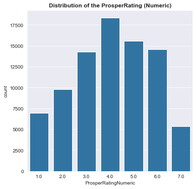

```python
# setting base color
base_color = sb.color_palette()[0]
# setting theme
sb.set_style("darkgrid")

# countplot
plt.figure(figsize=[6,6])
sb.countplot(data= loan, x= "ProsperRatingNumeric", color=base_color);
plt.title("Distribution of the ProsperRating (Numeric)", fontweight='bold');
```

**Observation**

- from the plot above, we can see the distribution of the Prosper Rating follows a normal distribution and is Unimodal
- The 4 rating is the most common rating given to customers with the `1` and `7` the least.

### Employment Status

The employment status of the borrower at the time they posted the listing.

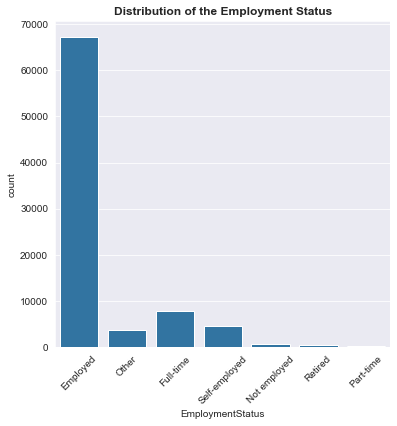

```python
# countplot
plt.figure(figsize=[6,6])
sb.countplot(data= loan, x= "EmploymentStatus", color=base_color);
plt.title("Distribution of the Employment Status", fontweight='bold');
plt.xticks(rotation=45);
```

**Observation**

- The 'Employed' persons make up most of the borrowers
- "Full-time" and "Self-employed" makes up most of the small groups

### Interest Rate

The Borrower's interest rate for this loan.

```python
loan.BorrowerRate.value_counts()
```

```
0.3177    3672
0.3199    1645
0.2699    1314
0.1099     932
0.3500     802
          ...
0.3094       1
0.1525       1
0.2125       1
0.2784       1
0.2665       1
Name: BorrowerRate, Length: 1229, dtype: int64
```

```python
#getting the statistical description
loan.BorrowerRate.describe()
```

```
count    84853.000000
mean         0.196022
std          0.074631
min          0.040000
25%          0.135900
50%          0.187500
75%          0.257400
max          0.360000
Name: BorrowerRate, dtype: float64
```

We have to bin the values in order to make inferences from the data

```python
# binning the values with the pandas cut()
bins = np.arange(0.04, loan.BorrowerRate.max()+0.025, 0.025)
loan['Binned_BorrowerRate'] = pd.cut(loan['BorrowerRate'], bins)
```

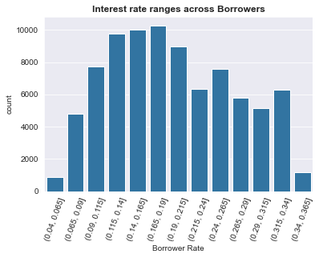

```python
# countplot
plt.title("Interest rate ranges across Borrowers", fontweight='bold')
plt.xticks(rotation=70)
plt.xlabel("Borrowers Rate")
ax = sb.countplot(data=loan, x='Binned_BorrowerRate', color=base_color);
ax.set(xlabel='Borrower Rate');
```

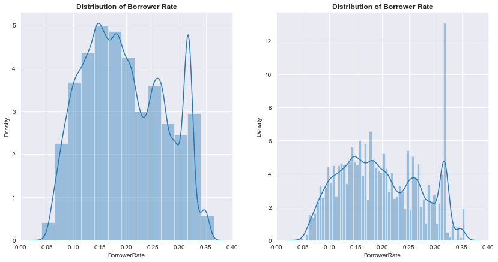

```python
plt.figure(figsize=[14,7])

plt.subplot(1,2,1)
bins = np.arange(0.04, loan.BorrowerRate.max()+0.025, 0.025)
sb.distplot(loan.BorrowerRate, bins=bins);
plt.title("Distribution of Borrower Rate", fontweight= 'bold');

plt.subplot(1,2,2)
bins = np.arange(0.04, loan.BorrowerRate.max()+0.005, 0.005)
sb.distplot(loan.BorrowerRate, bins=bins);
plt.title("Distribution of Borrower Rate", fontweight= 'bold');
```

### Loan Term

The length of the loan expressed in months.

```python
#Getting Value counts
loan.Term.value_counts()
```

```
36    58695
60    24545
12     1613
Name: Term, dtype: int64
```

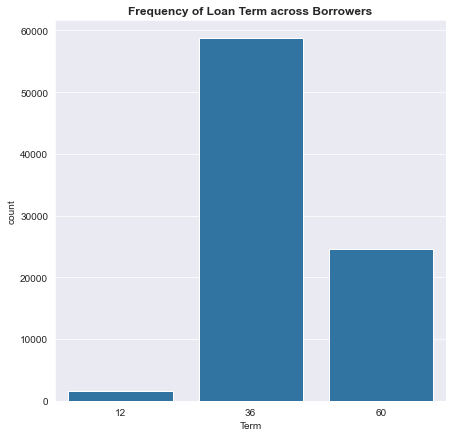

```python
# countplot
plt.figure(figsize=[7,7])
sb.countplot(data= loan, x= "Term", color=base_color);
plt.title("Frequency of Loan Term across Borrowers", fontweight='bold');
```

**Observation**

- The most loan period is 36 months (3 Years)
- The Least Popular Loan Term is the 12 Months Term (1 Year)
- There are only 3 value options for the loan length which are 12 months(1 Year), 36 Months (3 Years) and 60 months (5 Years), which tells us that these are the only length offered by the company

### Income Range

The income range of the borrower at the time the listing was created.

We'll look at the income range of the borrowers which is one of the features that are present as part of our exploratory process

```python
# checking the range of the income range column
loan.IncomeRange.value_counts()
```

```
$50,000-74,999    25627
$25,000-49,999    24175
$100,000+         15205
$75,000-99,999    14498
$1-24,999          4654
Not employed        649
$0                   45
Name: IncomeRange, dtype: int64
```

We have some rows with "Not Employed", I'll change them to $0 so that we can plot them together

```python
#replacing 'Not Employed' with '$0'
loan['IncomeRange'].replace(['Not employed'], '$0', inplace = True)
loan.IncomeRange.value_counts()
```

```
$50,000-74,999    25627
$25,000-49,999    24175
$100,000+         15205
$75,000-99,999    14498
$1-24,999          4654
$0                  694
Name: IncomeRange, dtype: int64
```

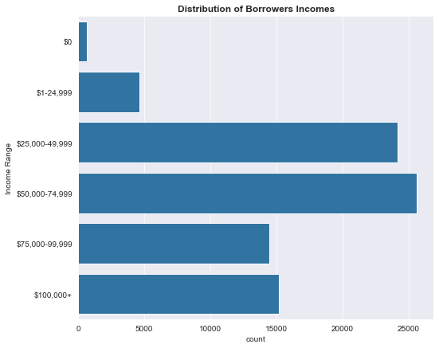

```python
# countplot
plt.figure(figsize=[8,7])
income_order = ['$0', '$1-24,999', '$25,000-49,999',
                '$50,000-74,999','$75,000-99,999', '$100,000+']
sb.countplot(data = loan, y = 'IncomeRange', color=base_color, order=income_order)
plt.ylabel('Income Range')

plt.title('Distribution of Borrowers Incomes', fontweight='bold');
```

**Observation**

- The Amount of people that have no income is only a small part of the total
- Most of the customers fall in the '$50,000-74,999' and '$25,000-49,999' range.
- Those that earn $75k to $100k is almost the same with those that earn $100k+

### Loan Status

The current status of the loan: Cancelled, Chargedoff, Completed, Current, Defaulted, FinalPaymentInProgress, PastDue. The PastDue status will be accompanied by a delinquency bucket.

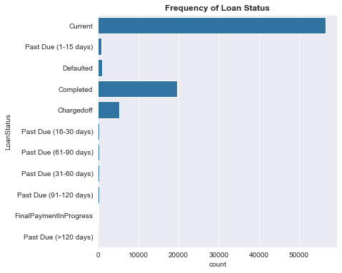

```python
#bar
plt.figure(figsize=[6,6])
sb.countplot(data= loan, y= "LoanStatus", color= base_color);
plt.title("Frequency of Loan Status", fontweight='bold');
```

```python
# getting stats
loan.LoanStatus.value_counts()
```

```
Current                   56576
Completed                 19664
Chargedoff                 5336
Defaulted                  1005
Past Due (1-15 days)        806
Past Due (31-60 days)       363
Past Due (61-90 days)       313
Past Due (91-120 days)      304
Past Due (16-30 days)       265
FinalPaymentInProgress      205
Past Due (>120 days)         16
Name: LoanStatus, dtype: int64
```

We need to do some adjustment to this, We need to change the Chargedoff to Defaulted

```python
# replacing Chargedoff to Defaulted
loan['LoanStatus'] = loan.LoanStatus.replace('Chargedoff','Defaulted')
```

```python
loan.LoanStatus.value_counts()
```

```
Current                   56576
Completed                 19664
Defaulted                  6341
Past Due (1-15 days)        806
Past Due (31-60 days)       363
Past Due (61-90 days)       313
Past Due (91-120 days)      304
Past Due (16-30 days)       265
FinalPaymentInProgress      205
Past Due (>120 days)         16
Name: LoanStatus, dtype: int64
```

We don't actually need the rest of the noise, so we're going to drop them

```python
def filter_rows_by_values(df, col, values):
    return df[df[col].isin(values)]

loan = filter_rows_by_values(loan, 'LoanStatus', ['Completed', 'Defaulted'])
```

```python
loan.LoanStatus.value_counts()
```

```
Completed    19664
Defaulted     6341
Name: LoanStatus, dtype: int64
```

We are now left with 19,664 Completed Loans and 6341 Defaulted, this would form the basic for our further analysis

**Observations**

- The current loans consist the bulk of the loans, so we dropped them so that it wouldn't hamper our analysis
- Among the lesser categories, we see the completed loans take the highest frequency

### Discuss the distribution(s) of your variable(s) of interest. Were there any unusual points? Did you need to perform any transformations?

> I looked at loan status, prosper rating, employment status, interest rate, loan term and income range.

> The majority of the loan status were the current loans

> The Prosper rating followed a normal distribution pattern, peaking at 4

> Majority of the Borrowers were employed, suprisingly, there were only little of unemployed

> The Most Popular Loan term was the 36 months option, there were only 3 possible options seen, which tells us that Prosper only offer 1,3,5 year loan terms

## Bivariate Exploration

We'll explore some relationships between some variables in this section in order to draw more conclusions

### Employment Status and Proper Rating

Does a borrower's Employment Status have an effect on his/her Prosper Rating?

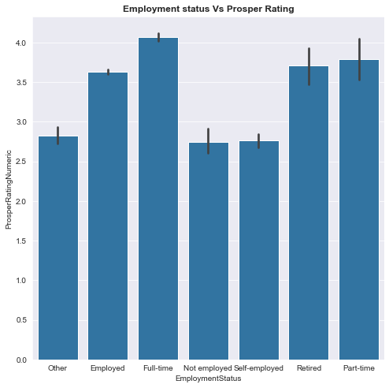

```python
# barplot
plt.figure(figsize=[8,8])

sb.barplot(data= loan, x= "EmploymentStatus", y= 'ProsperRatingNumeric', color= base_color);
plt.title("Employment status Vs Prosper Rating", fontweight= 'bold');
```

We can see some trends

- Lower Prosper Ratings are associated with `Other`, `Not Employed` and `Self Employed`
- Full-time and Part-time has the next largest rating

### Income range vs BorrowerRate

**What are the effects of a borrowers income range on his/her BorrowerRate?**

```python
# creating categorical data type
IncomeRange_list = list(loan.IncomeRange.value_counts().index)

incomes = pd.api.types.CategoricalDtype(ordered=True, categories= IncomeRange_list)

loan['IncomeRange'] = loan['IncomeRange'].astype(incomes)
```

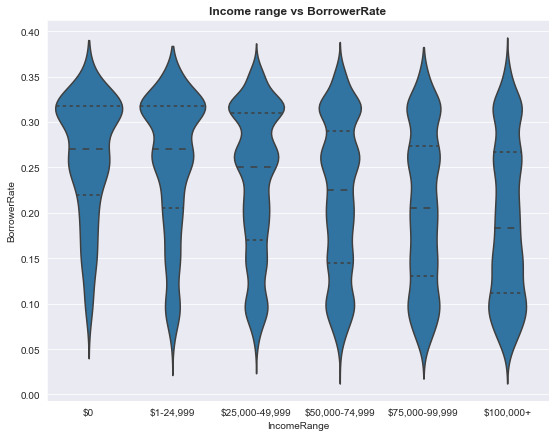

```python
# violin plot

plt.figure(figsize=[9,7])
sb.violinplot(data=loan, x='IncomeRange', y='BorrowerRate',
              inner='quartile', color=base_color, order= income_order);
plt.title("Income range vs BorrowerRate", fontweight= 'bold');
```

### Loan Status Vs Loan Amount

I thought that the amount of a loan should correlate to the status of the loan

```python
# creating categorical data type
LoanStatus_list = list(loan.LoanStatus.value_counts().index)

incomes = pd.api.types.CategoricalDtype(ordered=True, categories= LoanStatus_list)

loan['LoanStatus'] = loan['LoanStatus'].astype(incomes)
```

[figure not shown]

```python
# violin plot

plt.figure(figsize=[9,7])
sb.violinplot(data=loan, x='LoanStatus', y= 'LoanOriginalAmount', inner='quartile', color=base_color,);
plt.title("Income range vs Loan Amount", fontweight= 'bold');
```

Unfortunately, there was not much correlation between the Loan Amount and the Loan Status

We saw that they were similar with the defaulted having more at the 4000-5000 range

The Loan Amounts that were above 26000 were Completed

### Previous Deliquency vs Loan Status

Does Previous Credit Deliquency determine the posibility of the new loan to be defaulted?

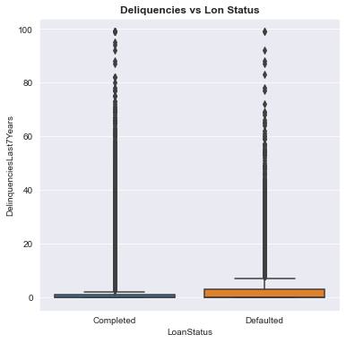

```python
plt.figure(figsize= [6,6])
sb.boxplot(data= loan, x= 'LoanStatus', y= "DelinquenciesLast7Years" );
plt.title("Deliquencies vs Lon Status", fontweight= 'bold');
```

There's no much difference between the effect of previous deliquency on the Loan Status

```python
loan.DelinquenciesLast7Years.value_counts()
```

```
0.0     18297
1.0       921
3.0       752
2.0       655
4.0       554
        ...
64.0        2
95.0        1
80.0        1
94.0        1
83.0        1
Name: DelinquenciesLast7Years, Length: 86, dtype: int64
```

### Loan Status vs Prosper Rating

I always felt that this would be the most decisive factor on the Loan Status

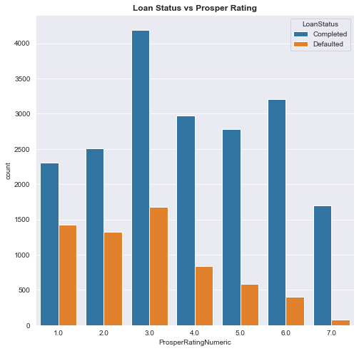

```python
plt.figure(figsize= [8,8])

sb.countplot(data= loan, x= "ProsperRatingNumeric", hue= "LoanStatus");
plt.title("Loan Status vs Prosper Rating", fontweight= 'bold');
```

There are a lot of interesting Observations

1. The '7' rating has the lowest percentage and counts of defaulters, which means that the ratings work
2. The '3' ratinh has the highest count of defaulters, and also the highest count of completed, which means that the percentage of defaulters would still be less
3. From rating '3' we saw the number of defaulters fall down to rating 7 which is the lowest

I'll do a violin plot in order to draw more inferences and get a feel for the relative frequency

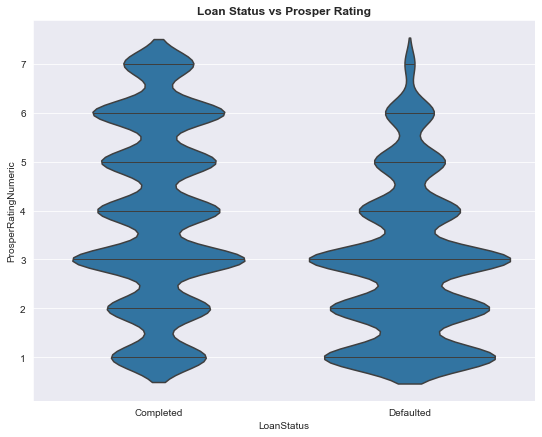

```python
# violin plot

plt.figure(figsize=[9,7])
sb.violinplot(data=loan, x='LoanStatus', y= 'ProsperRatingNumeric', inner= 'sticks', color=base_color,);
plt.title("Loan Status vs Prosper Rating", fontweight= 'bold');
```

## Multivariate Exploration

### Borrower Rate by Prosper rating and Loan Status

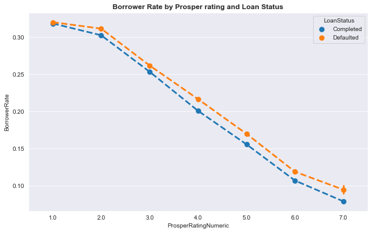

```python
#plot pointplot
fig = plt.figure(figsize = [10,6])
sb.pointplot(data = loan, x = 'ProsperRatingNumeric', y = 'BorrowerRate', hue = 'LoanStatus',
                  linestyles = 'dashed')
plt.title("Borrower Rate by Prosper rating and Loan Status", fontweight= 'bold');
```

**Observation**

- There's a strong correlation between the borrowerRate and the Ratings
- People with Higher ratings get lesser BorrowerRate and otherwise
- in every instance, the BorrowerRate of the defaulters were always greater than that of those that completed their loan

### Borrower Rate Vs Income Range Vs Prosper Rating

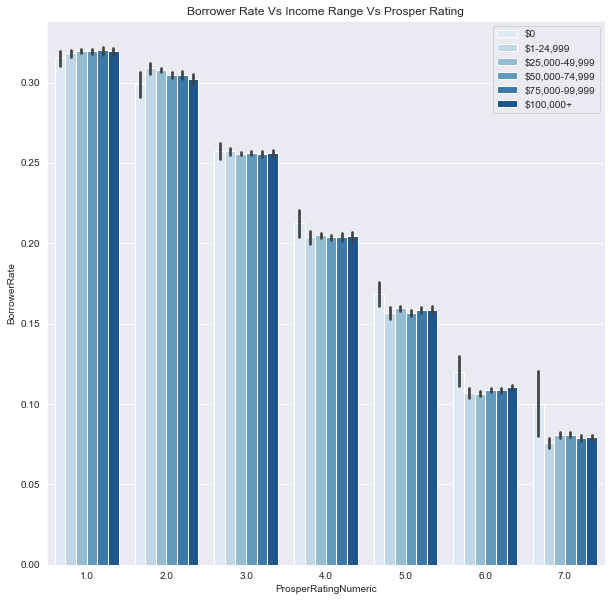

```python
plt.figure(figsize=[10, 10]);
sb.barplot(data = loan, x = 'ProsperRatingNumeric', y = 'BorrowerRate', hue = 'IncomeRange',
           palette= 'Blues', hue_order= income_order);
plt.title('Borrower Rate Vs Income Range Vs Prosper Rating');
plt.legend(loc= 'upper right');
```

There's a clear indication that the income range has little or no effect on the borrowerRate

### Evolution of BorrowerRate over years based on EmploymentStatus

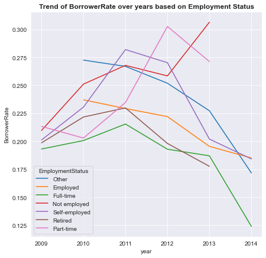

```python
plt.figure(figsize=(7,7))
sb.lineplot(data=loan, x='year', y='BorrowerRate', hue='EmploymentStatus', ci= None);
plt.title("Trend of BorrowerRate over years based on Employment Status", fontweight='bold');
```

The Full-time employers has the lowest rate in the year 2014

### Talk about some of the relationships you observed in this part of the investigation. Were there features that strengthened each other in terms of looking at your feature(s) of interest?

> The '7' rating has the lowest percentage and counts of defaulters, which means that the ratings work  
> The '3' rating has the highest count of defaulters, and also the highest count of completed, which means that the percentage of defaulters would still be less

### Were there any interesting or surprising interactions between features?

> There's a strong correlation between the borrowerRate and the Ratings  
> In every instance, the BorrowerRate of the defaulters were always greater than that of those that completed their loan